# Trabajo Final

Juan Arias

13/07/2022

## FACULTAD DE CIENCIAS SOCIALES - PUCP

### Curso: Estadística para el análisis político 2

### Semestre 2022-1

### **Nombres y apellidos del estudiante: Juan Sebastian Arias Palomino**

### **Código del estudiante: 20190983**

============================================================

#### TRABAJO FINAL: Factores asociados a la afectacción del acceso a los servicios básicos de saneamiento en zonas rurales en el Mundo

### Introducción:

Tras la experiencia de la Agenda de Desarrollo con los Objetivos de Desarrollo del Milenio en el 2015, la Asamblea General de las Naciones Unidas (AG-ONU) planteo una nueva Agenda hacia el 2030, posicionando 17 Objetivos de Desarrollo Sostenible (ODS), entre ellos, el 6 ODS en relación a Garantizar la disponibilidad de agua y su gestión sostenible y el saneamiento para todos.

Así, desde la organización se resalta que si bien se ha conseguido progresar de manera sustancial a la hora de ampliar el acceso a agua potable y saneamiento, existen miles de millones de personas (principalmente en áreas rurales) que aún carecen de estos servicios básicos. En todo el mundo, una de cada tres personas no tiene acceso a agua potable salubre, dos de cada cinco personas no disponen de una instalación básica destinada a lavarse las manos con agua y jabón, y más de 673 millones de personas aún defecan al aire libre.

Resaltando que a causa del crecimiento de la población, el desarrollo urbanistico y el crecimiento económico, las brechas entre las ciudadades y las zonas rurales se han agravado y lamentablemente el accionar del Estado en el mundo y, especialmente en Latinoamérica como señalan los informes de la Comisión Económica para América Latina y el Caribe (CEPAL), los gobiernos han accionado de forma limitada y con ineficiencia e irresponsabilidad en la gestión de recursos.

Frente a la lamentable realidad interna respecto al ineficiente acceso a servicios básicos de saneamiento, el presente informe busca analizar los factores asociados a dicha afectación en relación a variables de data recogida en diferentes países e instituciones por el Banco Mundial en el 2016.

En primer lugar, como variable dependiente, se utilizará el porcentaje de personas que utilizan al menos servicios básicos de saneamiento, es decir, instalaciones de saneamiento adecuadas que no se comparten con otros hogares. Este indicador abarca tanto a las personas que utilizan servicios de saneamiento básico como a las que utilizan servicios de saneamiento gestionados de forma segura. Las instalaciones de saneamiento mejoradas incluyen los sistemas de alcantarillado con cisternas o fosas sépticas o letrinas de pozo; las letrinas de pozo mejoradas ventiladas, los inodoros compuestos o las letrinas de pozo con losas.

En segundo lugar, como primera variable independiente, se considera el gasto público en educación (corriente, de capital y transferencias) se expresa en porcentaje del PIB. Incluye el gasto financiado por transferencias de fuentes internacionales al gobierno. Las administraciones públicas suelen referirse a las administraciones locales, regionales y centrales.

Finalmente, en tercer lugar, se considera la variable desempleo, que se refiere a la parte de la población activa que no tiene trabajo pero que está disponible y busca empleo.

Como ya se mencionó, la base de datos se desprende de data recogida en el mundo por el Banco Mundial correspondiente al año 2016.

### Selección de Variables:

De las cuales, se trabajaran principalmente sobre tres:

- Dependiente:
- BSS: Personas que utilizan al menos los servicios básicos de saneamiento en zonas rurales (% de la población rural)
- Datos recogidos del Programa de Monitoreo Conjunto OMS/UNICE (JMP) para el Abastecimiento de Agua, Saneamiento e Higiene.
- Independientes:
- GDE: Gasto público en educación, total (% del PBI)
- Datos recogidos del Instituto de Estadística de la UNESCO.
- UET: Desempleo, total (% de la población activa total)
- Datos recogidos de la Organización Internacional del Trabajo.

### Análisis Estadístico:

### Análisis de Regresión:

```
##
## Modelos planteadas
## =================================================================================================================
##                                                            Variable dependiente:
##                            --------------------------------------------------------------------------------------
##                             Personas que utilizan al menos los servicios básicos de saneamiento en zonas rurales
##                                        (1)                          (2)                          (3)
## -----------------------------------------------------------------------------------------------------------------
## Constante                            36.34***                     61.33***                     31.21***
##                                       (7.65)                       (4.31)                       (8.37)
##
## Gasto público en educación           6.22***                                                   7.73***
##                                       (1.55)                                                    (1.75)
##
## Desempleo                                                           0.53                        -0.18
##                                                                    (0.43)                       (0.49)
##
## -----------------------------------------------------------------------------------------------------------------
## Observations                           127                          161                          124
## Adjusted R2                            0.11                        0.003                         0.13
## Residual Std. Error                   31.35                        32.78                        30.98
## =================================================================================================================
## Notas:                                                                                *p<0.1; **p<0.05; ***p<0.01
```

Se realiza una regresión lineal multivariada con las mismas variables, manteniendo Personas que utilizan al menos los servicios básicos de saneamiento en zonas rurales (BSS) como variable dependiente y Gasto público en educación (GDE) y Desempleo (UET) como variables independientes

Este modelo si aporta pues su p-value es menor a 0.05, explicando un 12.76%. Sin embargo, la única variable que explica Personas que utilizan al menos los servicios básicos de saneamiento en zonas rurales (BSS) es Gasto público en educación (GDE), pues su p-value es menor a 0.05.

### Análisis de Conglomerados:

### Clusterización:

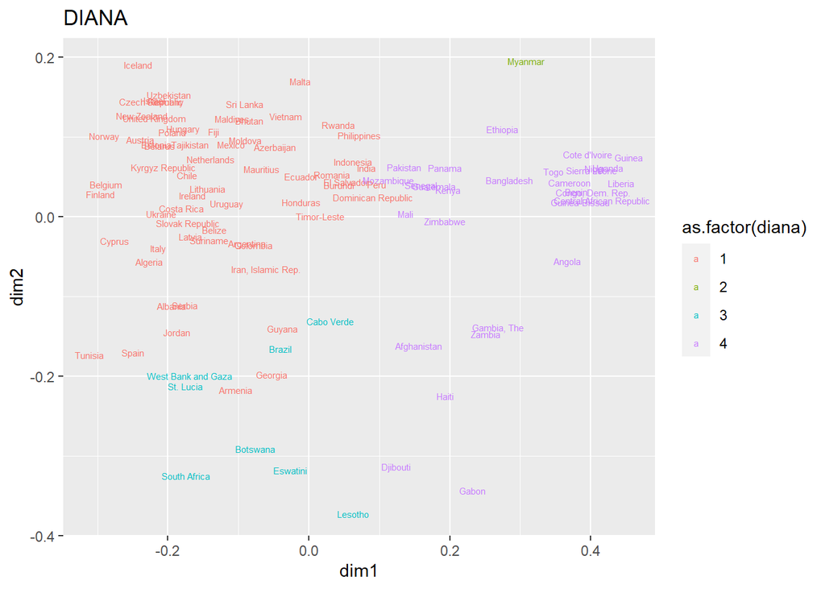

Se recodificaron los clusters en función del BSS (Personas que utilizan al menos los servicios básicos de saneamiento en zonas rurales), se tomo está decisión porque es la variable dependiente y la que más nos interesa analizar.

### Proceso del Analisis Factorial Exploratorio (EFA)

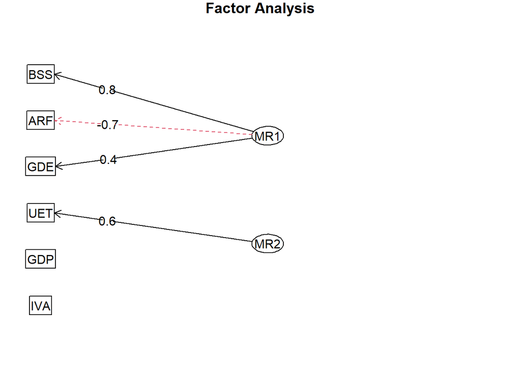

### Conclusiones

De acuerdo a los resultados obtenidos, de las variables planteadas principalmente en relación a la afectación de Personas que utilizan al menos los servicios básicos de saneamiento en zonas rurales (% de la población rural), solo una, el Gasto público en educación, total (% del PBI), tiene cierta capacidad para explicar la realidad. Respecto a la variable Desempleo, total (% de la población activa total), si bien puede ejercer una afectación al modelo, esta es mínima y muy limitada.

Así, desde la visión profesional, el Estado debería fortalecer sus capacidades de gestió y promoción de un mejor sistema educativo para fortalecer las capacidades de desarrollo sostenible y accesible para las personas que viven en zonas rurales.

### Análisis Estadístico:

### Análisis de Regresión:

```
## [1] 50
```

```
## [1] 67
```

```
## [1] 30
```

### Regresión Lineal 1:

- Analizar si la variable independiente Gasto público en educación (GDE), afecta a la variable dependiente Personas que utilizan al menos los servicios básicos de saneamiento en zonas rurales (BSS)

[figure not shown]

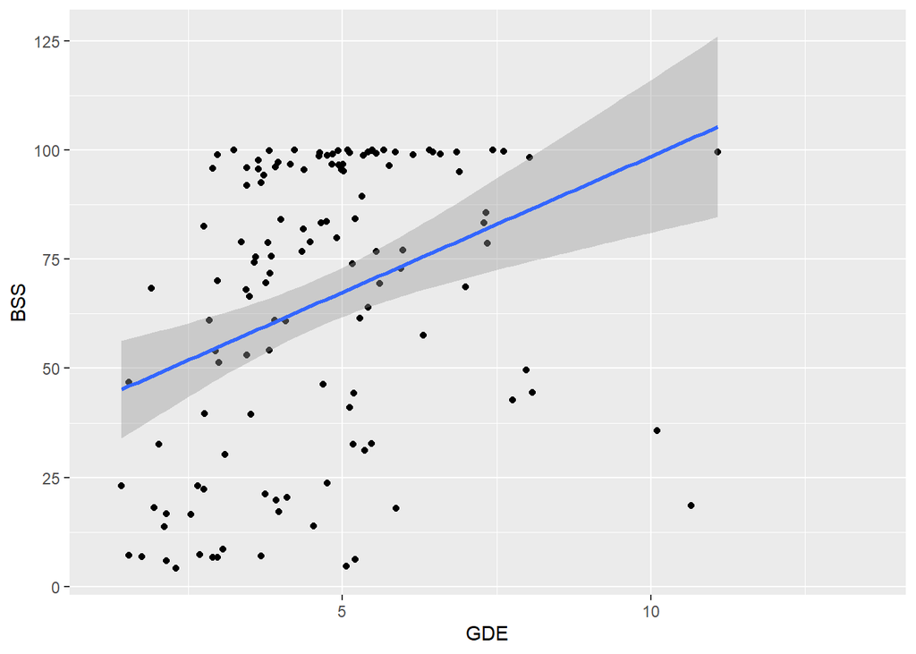

- Prueba de normalidad y correlación

```
##
##  Lilliefors (Kolmogorov-Smirnov) normality test
##
## data:  data1$BSS
## D = 0.14967, p-value = 2.257e-07
```

```
##
##  Lilliefors (Kolmogorov-Smirnov) normality test
##
## data:  data1$GDE
## D = 0.09597, p-value = 0.001783
```

Ambos p-values son menores a 0.05 por lo que no presentan normalidad y podemos continuar haciendo las pruebas de correlación con Spearman.

```
##
##  Spearman's rank correlation rho
##
## data:  data1$BSS and data1$GDE
## S = 196085, p-value = 6.095e-07
## alternative hypothesis: true rho is not equal to 0
## sample estimates:
##       rho
## 0.4256044
```

El p-value es menor a 0.05 por lo que se rechaza la Hipótesis nula y se demuestra que hay correlación entre las dos variables, por lo que es necesario crear el modelo de regresión lineal.

Las hipótesis para la prueba F son las siguientes:

H0:El modelo de regresión no es válido H1:El modelo de regresión es válido

```
## Analysis of Variance Table
##
## Response: BSS
##            Df Sum Sq Mean Sq F value    Pr(>F)
## GDE         1  15797 15797.4  16.078 0.0001039 ***
## Residuals 125 122816   982.5
## ---
## Signif. codes:  0 '***' 0.001 '**' 0.01 '*' 0.05 '.' 0.1 ' ' 1
```

```
##
## Call:
## lm(formula = BSS ~ GDE, data = data1)
##
## Residuals:
##     Min      1Q  Median      3Q     Max
## -84.105 -30.057   9.895  28.206  44.007
##
## Coefficients:
##             Estimate Std. Error t value Pr(>|t|)
## (Intercept)   36.335      7.651   4.749  5.5e-06 ***
## GDE            6.223      1.552   4.010 0.000104 ***
## ---
## Signif. codes:  0 '***' 0.001 '**' 0.01 '*' 0.05 '.' 0.1 ' ' 1
##
## Residual standard error: 31.35 on 125 degrees of freedom
##   (23 observations deleted due to missingness)
## Multiple R-squared:  0.114,  Adjusted R-squared:  0.1069
## F-statistic: 16.08 on 1 and 125 DF,  p-value: 0.0001039
```

El p-value es menor a 0.05, por lo que nuevamente se rechaza la hipótesis nula y se demuestra que hay relación entre las variables, es decir, que el GDE explica el BSS.

Como el coeficiente R-cuadrado ajustado es 0.1069, significa que este modelo de regresión explica en un 10.69%.

```
##
## ===============================================
##                         Dependent variable:
##                     ---------------------------
##                                 BSS
## -----------------------------------------------
## Constant                     36.335***
##                               (7.651)
##
## GDE                          6.223***
##                               (1.552)
##
## -----------------------------------------------
## Observations                    127
## R2                             0.114
## Adjusted R2                    0.107
## Residual Std. Error      31.345 (df = 125)
## F Statistic           16.078*** (df = 1; 125)
## ===============================================
## Note:               *p<0.1; **p<0.05; ***p<0.01
```

- Ecuación

- Gráfico de la ecuación

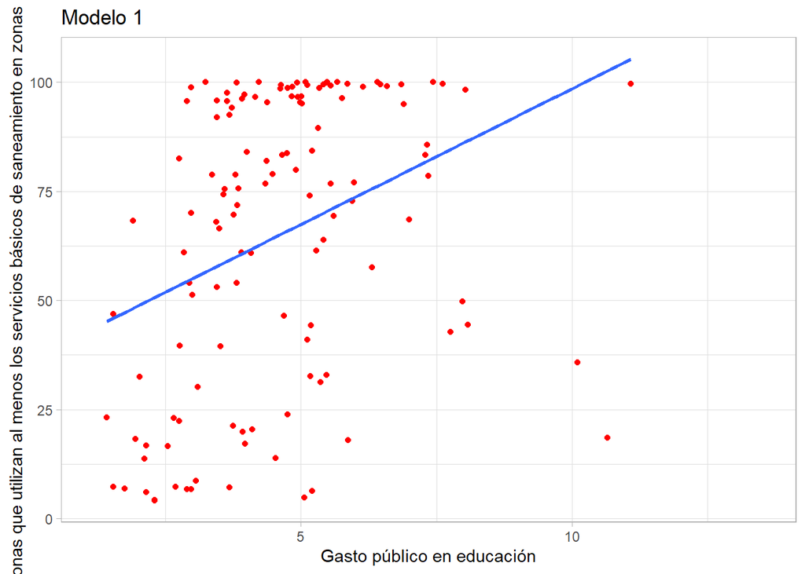

### Regresión Lineal 2:

- Analizar si la variable independiente Desempleo (UET), afecta a la variable Personas que utilizan al menos los servicios básicos de saneamiento en zonas rurales (BSS)

[figure not shown]

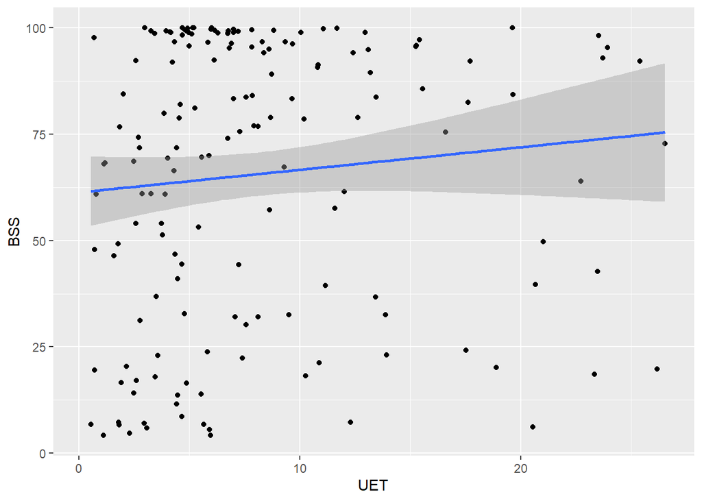

- Prueba de normalidad y correlación

```
##
##  Spearman's rank correlation rho
##
## data:  data2$BSS and data2$UET
## S = 569236, p-value = 0.02116
## alternative hypothesis: true rho is not equal to 0
## sample estimates:
##       rho
## 0.1815677
```

El p-value es menor a 0.05 por lo que se rechaza la Hipótesis nula y se demuestra que hay correlación entre las dos variables, por lo que es necesario crear el modelo de regresión lineal.

Las hipótesis para la prueba F son las siguientes:

H0:El modelo de regresión no es válido H1:El modelo de regresión es válido

```
## Analysis of Variance Table
##
## Response: BSS
##            Df Sum Sq Mean Sq F value Pr(>F)
## UET         1   1675  1674.7  1.5586 0.2137
## Residuals 159 170848  1074.5
```

```
##
## Call:
## lm(formula = BSS ~ UET, data = data2)
##
## Residuals:
##    Min     1Q Median     3Q    Max
## -66.02 -31.55  11.14  29.97  37.09
##
## Coefficients:
##             Estimate Std. Error t value Pr(>|t|)
## (Intercept)  61.3270     4.3052  14.245   <2e-16 ***
## UET           0.5311     0.4254   1.248    0.214
## ---
## Signif. codes:  0 '***' 0.001 '**' 0.01 '*' 0.05 '.' 0.1 ' ' 1
##
## Residual standard error: 32.78 on 159 degrees of freedom
##   (26 observations deleted due to missingness)
## Multiple R-squared:  0.009707,   Adjusted R-squared:  0.003479
## F-statistic: 1.559 on 1 and 159 DF,  p-value: 0.2137
```

El p-value es mayor a 0.05, por lo que se acepta la hipótesis nula y se demuestra que no hay relación entre las variables, es decir, que el UET no explica el BSS.

```
##
## ===============================================
##                         Dependent variable:
##                     ---------------------------
##                                 BSS
## -----------------------------------------------
## Constant                     61.327***
##                               (4.305)
##
## UET                            0.531
##                               (0.425)
##
## -----------------------------------------------
## Observations                    161
## R2                             0.010
## Adjusted R2                    0.003
## Residual Std. Error      32.780 (df = 159)
## F Statistic             1.559 (df = 1; 159)
## ===============================================
## Note:               *p<0.1; **p<0.05; ***p<0.01
```

### Regresión Lineal Multivariada:

- Ahora vamos a hacer una regresión lineal multivariada con las mismas variables, manteniendo Personas que utilizan al menos los servicios básicos de saneamiento en zonas rurales (BSS) como variable dependiente y Gasto público en educación (GDE) y Desempleo (UET) como variables independientes

```
##
## ===============================================
##                         Dependent variable:
##                     ---------------------------
##                                 BSS
## -----------------------------------------------
## GDE                          7.725***
##                               (1.750)
##
## UET                           -0.182
##                               (0.486)
##
## Constant                     31.210***
##                               (8.371)
##
## -----------------------------------------------
## Observations                    124
## R2                             0.142
## Adjusted R2                    0.128
## Residual Std. Error      30.980 (df = 121)
## F Statistic           9.994*** (df = 2; 121)
## ===============================================
## Note:               *p<0.1; **p<0.05; ***p<0.01
```

```
##
## Call:
## lm(formula = modelo3, data = data3)
##
## Residuals:
##     Min      1Q  Median      3Q     Max
## -90.738 -28.241   9.666  26.083  45.560
##
## Coefficients:
##             Estimate Std. Error t value Pr(>|t|)
## (Intercept)  31.2100     8.3707   3.728 0.000294 ***
## GDE           7.7252     1.7505   4.413 2.23e-05 ***
## UET          -0.1817     0.4862  -0.374 0.709311
## ---
## Signif. codes:  0 '***' 0.001 '**' 0.01 '*' 0.05 '.' 0.1 ' ' 1
##
## Residual standard error: 30.98 on 121 degrees of freedom
##   (63 observations deleted due to missingness)
## Multiple R-squared:  0.1418, Adjusted R-squared:  0.1276
## F-statistic: 9.994 on 2 and 121 DF,  p-value: 9.612e-05
```

Este modelo si aporta pues su p-value es menor a 0.05, explicando un 12.76%. Sin embargo, la única variable que explica Personas que utilizan al menos los servicios básicos de saneamiento en zonas rurales (BSS) es Gasto público en educación (GDE), pues su p-value es menor a 0.05.

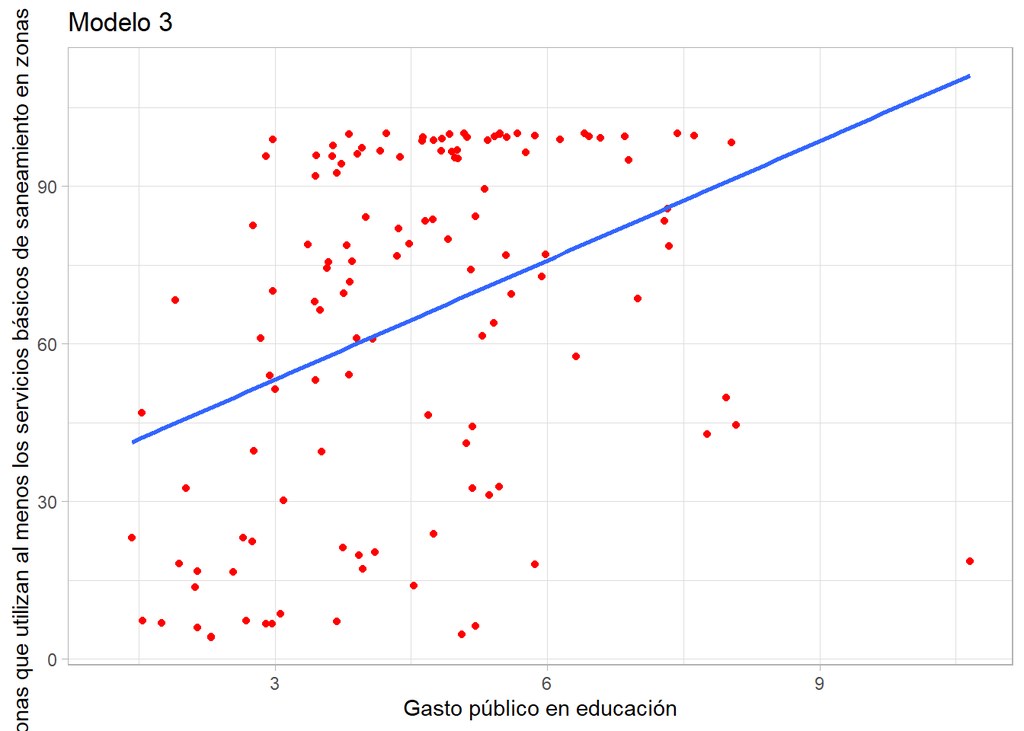

```
##
## Modelos planteadas
## =================================================================================================================
##                                                            Variable dependiente:
##                            --------------------------------------------------------------------------------------
##                             Personas que utilizan al menos los servicios básicos de saneamiento en zonas rurales
##                                        (1)                          (2)                          (3)
## -----------------------------------------------------------------------------------------------------------------
## Constante                            36.34***                     61.33***                     31.21***
##                                       (7.65)                       (4.31)                       (8.37)
##
## Gasto público en educación           6.22***                                                   7.73***
##                                       (1.55)                                                    (1.75)
##
## Desempleo                                                           0.53                        -0.18
##                                                                    (0.43)                       (0.49)
##
## -----------------------------------------------------------------------------------------------------------------
## Observations                           127                          161                          124
## Adjusted R2                            0.11                        0.003                         0.13
## Residual Std. Error                   31.35                        32.78                        30.98
## =================================================================================================================
## Notas:                                                                                *p<0.1; **p<0.05; ***p<0.01
```

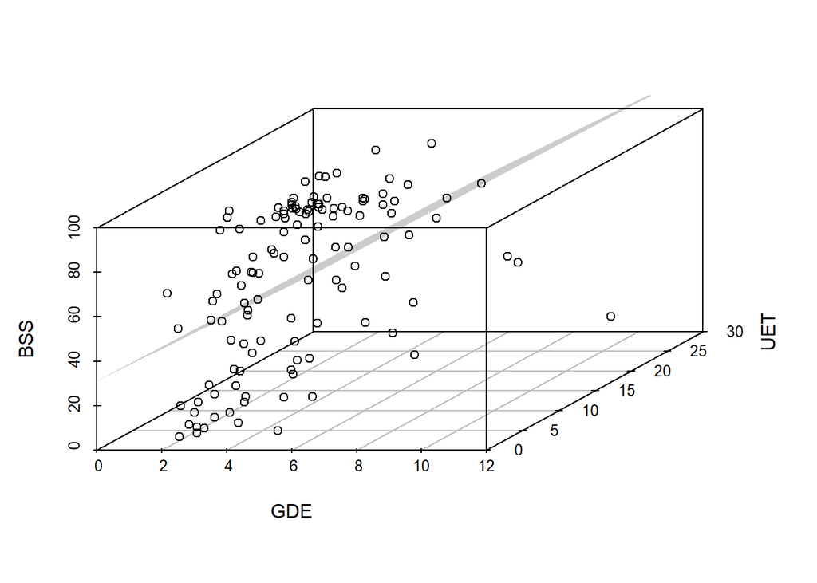

### DIAGNÓSTICOS DE REGRESIÓN:

- Linealidad:

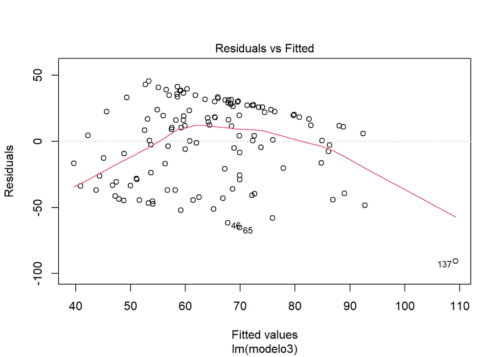

El análisis de linealidad no sale muy bien pues la linea roja no está cerca de la linea horizontal

- Homocedasticidad:

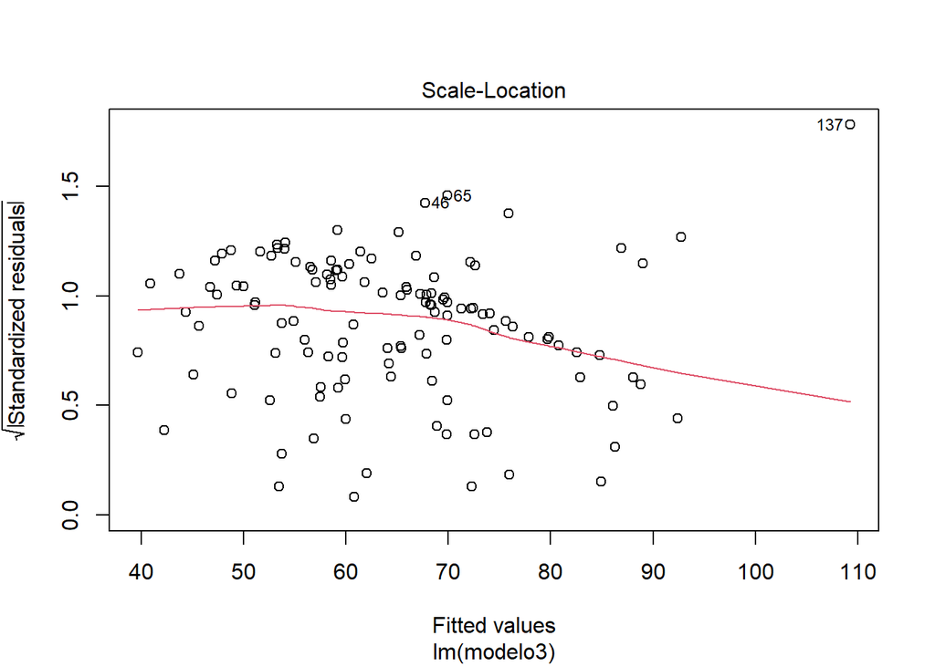

```
##
##  studentized Breusch-Pagan test
##
## data:  reg3
## BP = 2.9467, df = 2, p-value = 0.2292
```

La probabilidad de homocedasticidad es alta pues tiene un p-valor mayor a 0.05, por lo que se acepta que este modelo tiene homocedasticidad.

- Normalidad de residuos:

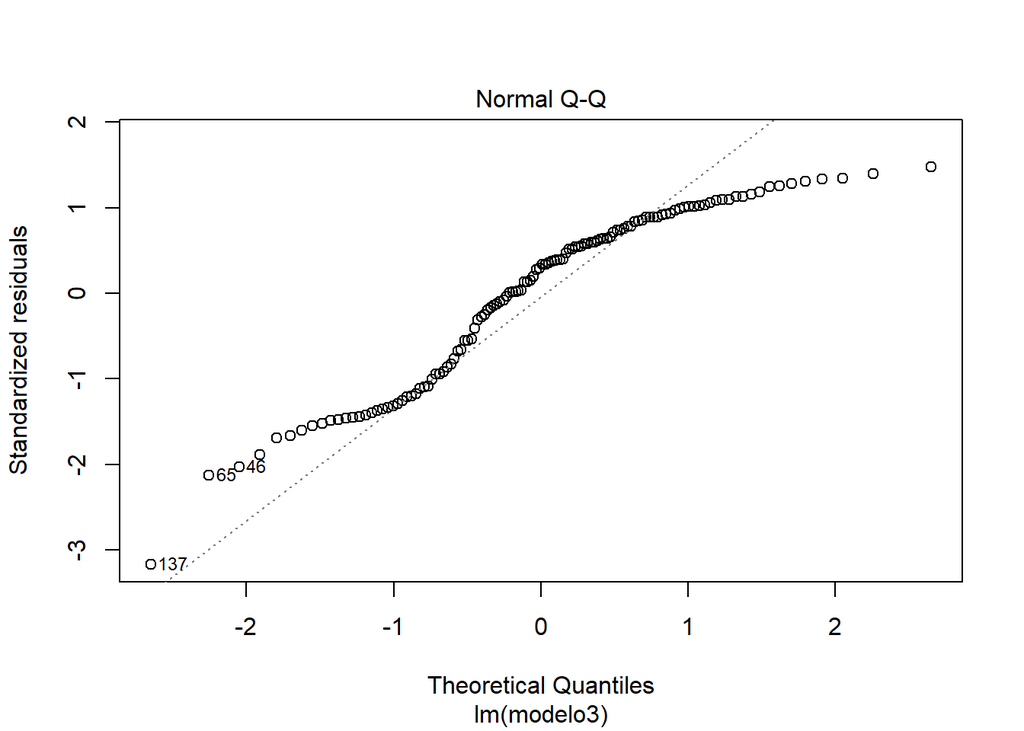

```
##
##  Shapiro-Wilk normality test
##
## data:  reg3$residuals
## W = 0.92845, p-value = 5.609e-06
```

En este caso, la prueba de normalidad de residuos muestra un p-valor menor a 0.05, lo cual no es positivo porque muestra que los residuos no se distribuyen de manera normal, esto se ve expresado en el gráfico porque los valores no están del todo cerca de la línea diagonal.

- No multicolinealidad:

```
##      GDE      UET
## 1.062263 1.062263
```

Como ninguna variable sale mayor a 5, ninguna es candidata a ser retirada y muestra que estas no están muy correlacionadas entre sí, es decir, muestra que estas no tratan de explicar el mismo fenómeno.

- Valores influyentes:

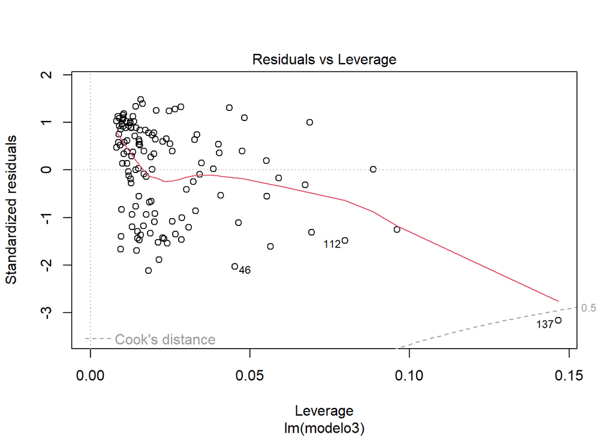

El gráfico muestra que efectivamente hay valores atípicos que influyen negativamente en la regresión.

### Análisis de Conglomerados:

- Configuración de data

```
## 'data.frame':    217 obs. of  7 variables:
##  $ Country Name: chr  "Afghanistan" "Albania" "Algeria" "American Samoa" ...
##  $ ARF         : num  68.8 20.7 10.4 NA NA ...
##  $ GDE         : num  3.51 3.96 7.34 NA 3.24 ...
##  $ BSS         : num  39.4 97.2 78.6 NA 100 ...
##  $ UET         : num  11.2 15.4 10.2 NA NA ...
##  $ GDP         : num  2.26 3.31 3.2 -1.68 3.71 ...
##  $ IVA         : num  1.09 4.54 3.91 NA 11.64 ...
```

```
##  Country Name            ARF                GDE              BSS
##  Length:217         Min.   :  0.2864   Min.   : 1.190   Min.   :  4.157
##  Class :character   1st Qu.: 13.5066   1st Qu.: 3.311   1st Qu.: 36.742
##  Mode  :character   Median : 37.3040   Median : 4.401   Median : 76.774
##                     Mean   : 46.8218   Mean   : 4.561   Mean   : 66.106
##                     3rd Qu.: 68.5066   3rd Qu.: 5.418   3rd Qu.: 96.644
##                     Max.   :194.0090   Max.   :13.513   Max.   :100.000
##                     NA's   :23         NA's   :67       NA's   :50
##       UET              GDP               IVA
##  Min.   : 0.150   Min.   :-10.783   Min.   :-25.6523
##  1st Qu.: 3.880   1st Qu.:  1.587   1st Qu.:  0.1305
##  Median : 6.010   Median :  3.146   Median :  3.0108
##  Mean   : 7.993   Mean   :  3.136   Mean   :  3.0005
##  3rd Qu.:10.830   3rd Qu.:  4.739   3rd Qu.:  5.6152
##  Max.   :26.540   Max.   : 29.212   Max.   : 41.7137
##  NA's   :30       NA's   :11        NA's   :36
```

- Distribución

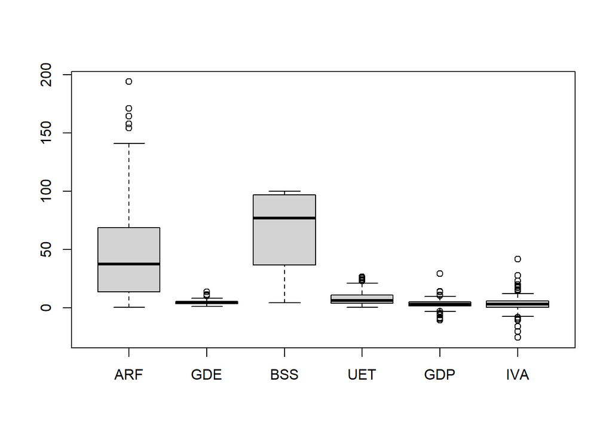

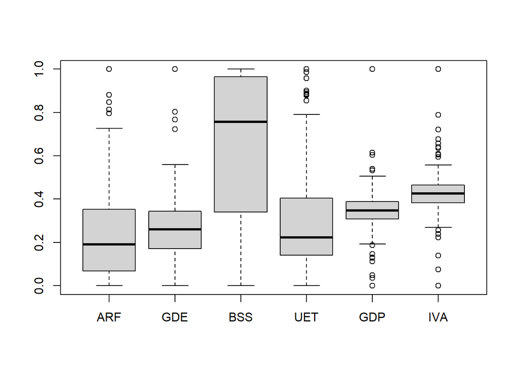

```
##  Country Name            ARF                GDE                 BSS
##  Length:102         Min.   :-1.05635   Min.   :-1.633671   Min.   :-1.89394
##  Class :character   1st Qu.:-0.68935   1st Qu.:-0.578512   1st Qu.:-0.70222
##  Mode  :character   Median :-0.04509   Median :-0.006289   Median : 0.32603
##                     Mean   : 0.12422   Mean   :-0.017470   Mean   : 0.03545
##                     3rd Qu.: 0.83228   3rd Qu.: 0.478248   3rd Qu.: 0.92439
##                     Max.   : 3.11611   Max.   : 1.831137   Max.   : 1.03781
##       UET                 GDP                IVA
##  Min.   :-1.246116   Min.   :-2.06096   Min.   :-4.07294
##  1st Qu.:-0.624513   1st Qu.:-0.27702   1st Qu.:-0.36723
##  Median :-0.331335   Median : 0.05804   Median : 0.02427
##  Mean   : 0.003705   Mean   : 0.11216   Mean   :-0.03193
##  3rd Qu.: 0.278825   3rd Qu.: 0.61823   3rd Qu.: 0.33297
##  Max.   : 3.098257   Max.   : 2.62639   Max.   : 5.50300
```

- Correlaciones:

```
##             ARF         GDE         BSS         UET         GDP         IVA
## ARF  1.00000000 -0.40936398 -0.61355620 -0.16524059  0.07992886  0.01830289
## GDE -0.40936398  1.00000000  0.45079864  0.16313532 -0.14449506  0.01081636
## BSS -0.61355620  0.45079864  1.00000000  0.14286429 -0.19512529  0.04457353
## UET -0.16524059  0.16313532  0.14286429  1.00000000 -0.09898457 -0.10405277
## GDP  0.07992886 -0.14449506 -0.19512529 -0.09898457  1.00000000  0.20014427
## IVA  0.01830289  0.01081636  0.04457353 -0.10405277  0.20014427  1.00000000
```

- Cambio de monotonía:

```
##             ARF         GDE         BSS         UET         GDP         IVA
## ARF  1.00000000 -0.40936398  0.61355620 -0.16524059  0.07992886  0.01830289
## GDE -0.40936398  1.00000000 -0.45079864  0.16313532 -0.14449506  0.01081636
## BSS  0.61355620 -0.45079864  1.00000000 -0.14286429  0.19512529 -0.04457353
## UET -0.16524059  0.16313532 -0.14286429  1.00000000 -0.09898457 -0.10405277
## GDP  0.07992886 -0.14449506  0.19512529 -0.09898457  1.00000000  0.20014427
## IVA  0.01830289  0.01081636 -0.04457353 -0.10405277  0.20014427  1.00000000
```

- Preparamos la data para la clusterización:

### Clusterización:

- Calcular distancia entre los casos:
- Cantidad de clusters a solicitar:

Para PAM

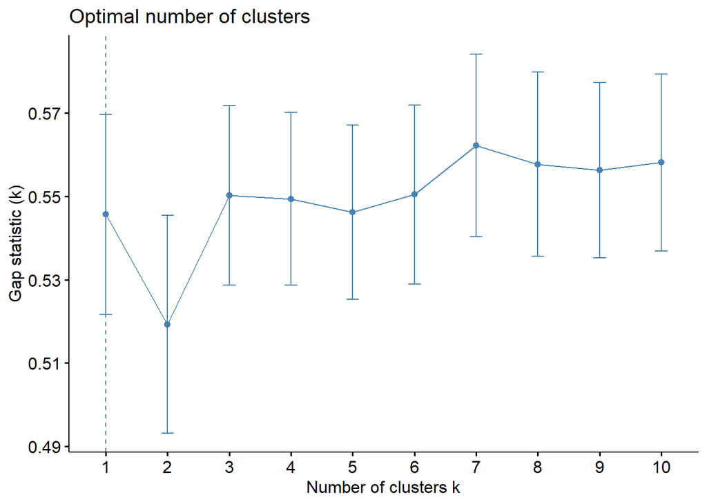

Para Jerárquico

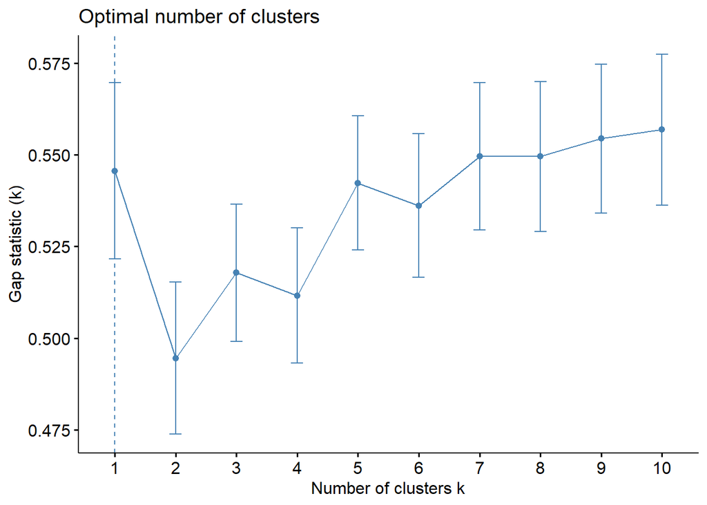

Para Jerárquico

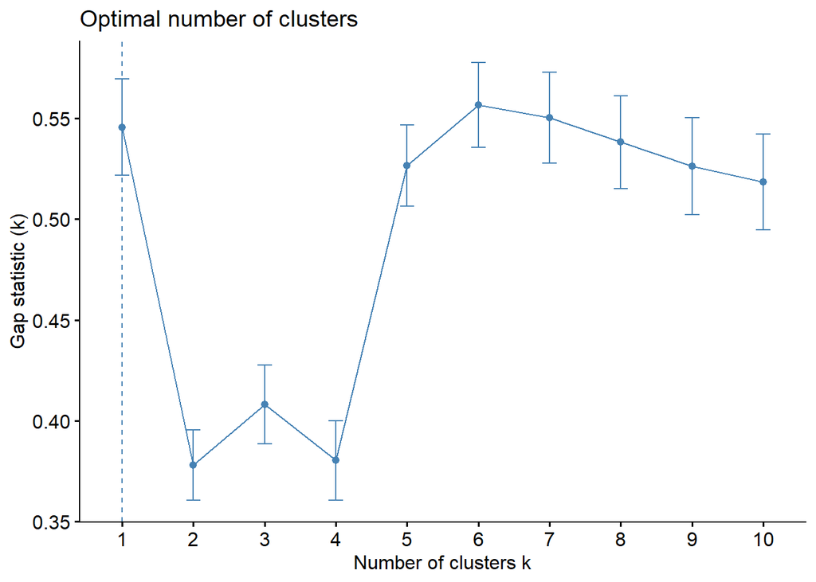

- Pidamos cuatro grupos:

PAM

Agnes

Diana

- Evaluamos:

```
##   cluster size ave.sil.width
## 1       1   25          0.01
## 2       2   37          0.35
## 3       3   20          0.28
## 4       4   20          0.15
```

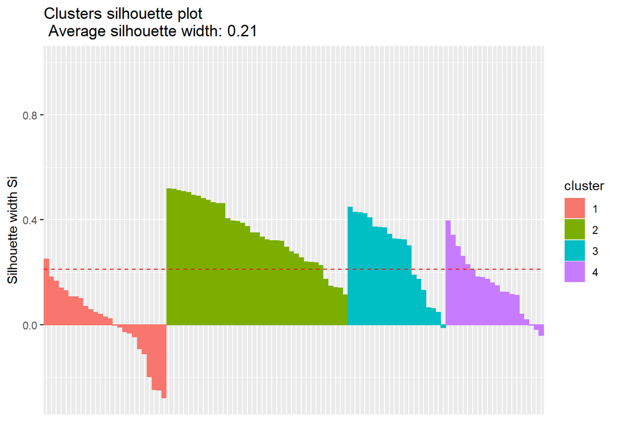

```
##   cluster size ave.sil.width
## 1       1   18          0.30
## 2       2   14          0.10
## 3       3   50          0.31
## 4       4   20          0.13
```

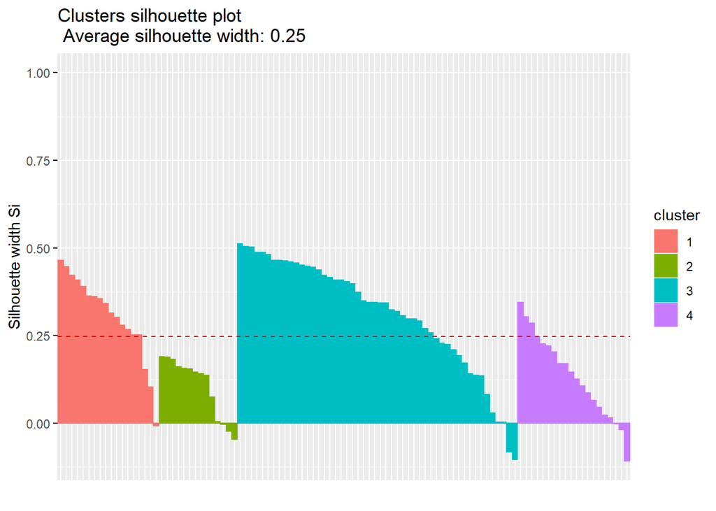

```
##   cluster size ave.sil.width
## 1       1   29          0.31
## 2       2   64          0.32
## 3       3    8          0.22
## 4       4    1          0.00
```

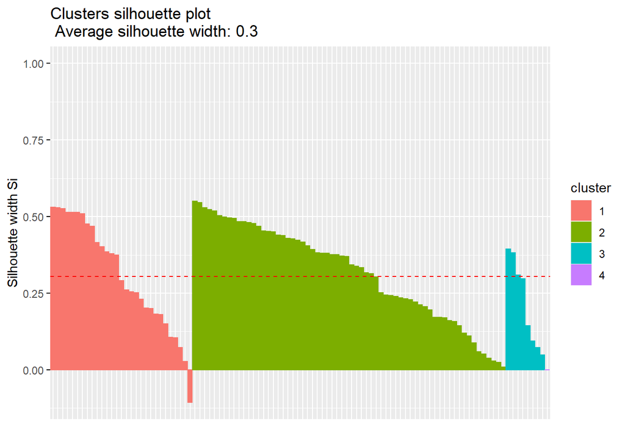

- Gráfico:

Se va a recodificar los clusters en función del BSS (Personas que utilizan al menos los servicios básicos de saneamiento en zonas rurales), se tomo está decisión porque es la variable dependiente y la que más nos interesa analizar

```
##   diana        ARF        GDE          BSS         UET         GDP         IVA
## 2     2 -0.3300219  0.2146900 -0.637139389 -0.09726566 0.002077891 -0.07600233
## 4     4  2.3102275 -1.3852247 -0.067109599 -1.13870106 1.887025011  5.50299833
## 3     3  0.3311623  0.8068793  0.003660126  2.02579964 0.038624427  0.05456473
## 1     1  0.9942179 -0.7100650  1.282721949 -0.29188774 0.314191606 -0.14937345
##        pam    agnes
## 2 2.046875 3.031250
## 4 3.000000 4.000000
## 3 1.375000 2.250000
## 1 3.241379 2.068966
```

Proyectando los casos en dos dimensiones:

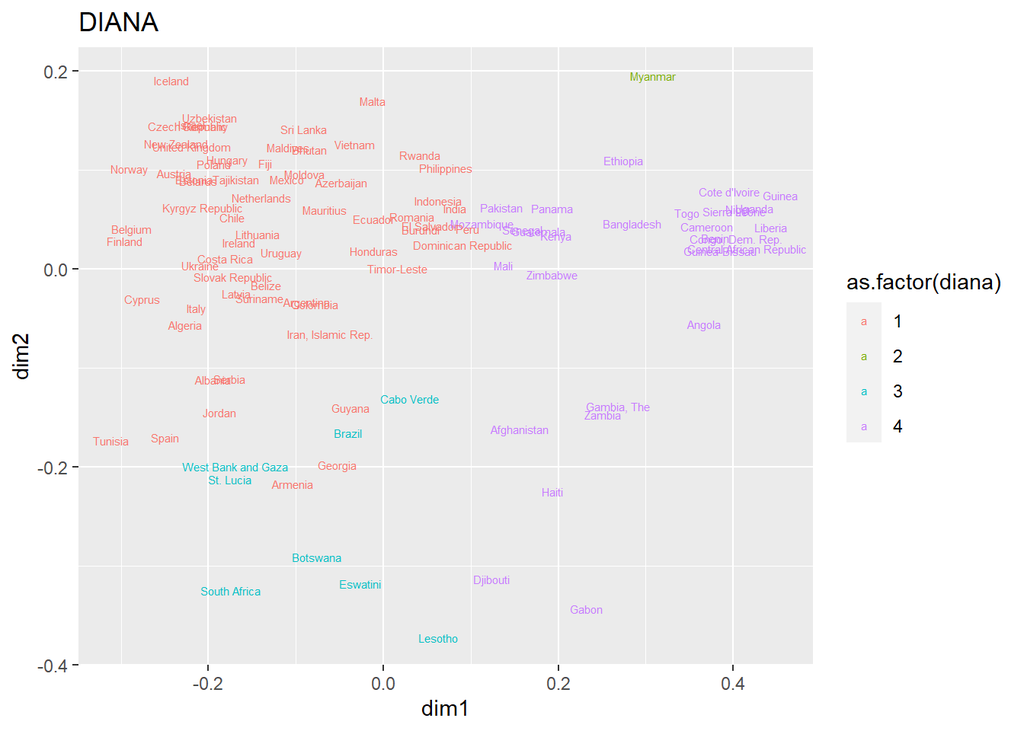

### Proceso del Analisis Factorial Exploratorio (EFA)

- Calculemos matriz de correlación:
- Explorar correlaciones:

Sin evaluar significancia

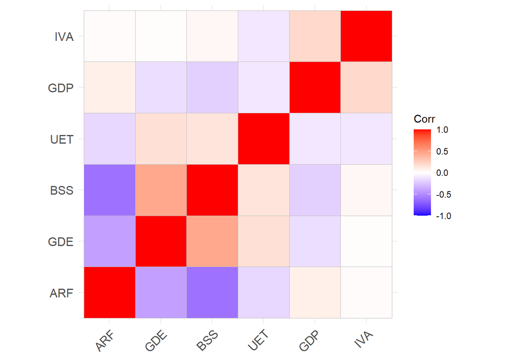

- Verificar si los datos permiten factorizar:

```
## Kaiser-Meyer-Olkin factor adequacy
## Call: psych::KMO(r = corMatrix)
## Overall MSA =  0.65
## MSA for each item =
##  ARF  GDE  BSS  UET  GDP  IVA
## 0.64 0.79 0.62 0.78 0.56 0.43
```

- Verificar si la matriz de correlaciones es adecuada

```
## [1] FALSE
```

Prueba Hnula: La matriz de correlacion es una matriz singular

```
## [1] FALSE
```

- Determinar en cuantos factores o variables latentes podríamos redimensionar la data:

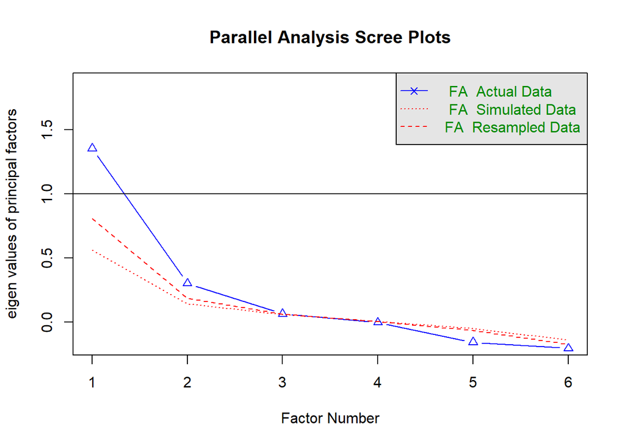

```
## Parallel analysis suggests that the number of factors =  2  and the number of components =  NA
```

Se sugiere 2.

- Redimensionar a numero menor de factores

Resultado inicial:

```
##
## Loadings:
##     MR1    MR2
## ARF -0.671
## GDE  0.419  0.292
## BSS  0.840
## UET  0.142  0.559
## GDP        -0.293
## IVA        -0.126
##
##                  MR1   MR2
## SS loadings    1.353 0.504
## Proportion Var 0.226 0.084
## Cumulative Var 0.226 0.310
```

- Resultado mejorado:

```
##
## Loadings:
##     MR1    MR2
## ARF -0.671
## GDE
## BSS  0.840
## UET         0.559
## GDP
## IVA
##
##                  MR1   MR2
## SS loadings    1.353 0.504
## Proportion Var 0.226 0.084
## Cumulative Var 0.226 0.310
```

- Resultado visual:

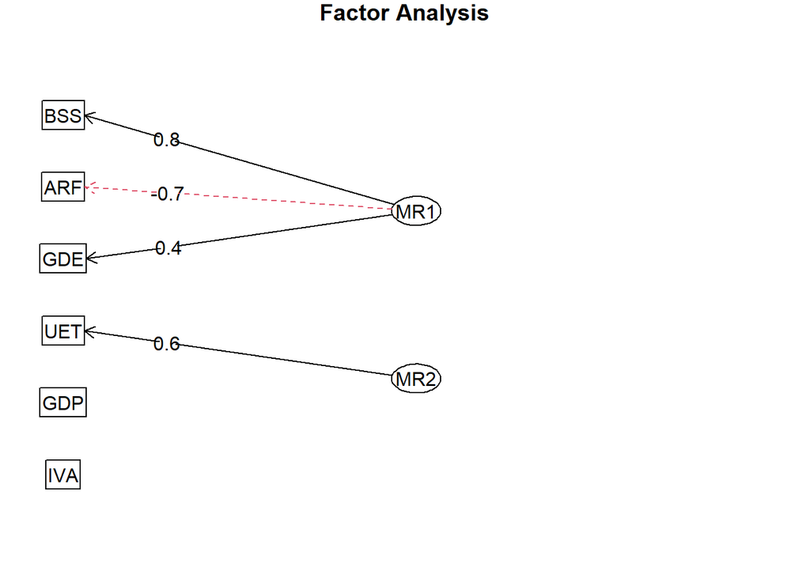

- Evaluación:

Variables que más aportaron a los factores

```
##        IVA        GDP        GDE        UET        ARF        BSS
## 0.01701129 0.08606024 0.26097058 0.33326639 0.45309471 0.70739850
```

Variables que contribuyen a mas de un factor

```
##      BSS      GDP      ARF      UET      IVA      GDE
## 1.002727 1.010346 1.015438 1.129005 1.138898 1.786854
```